% Troubles hydro-électolytiques et Acido-basiques % Dr Jeanclaude.Bartier@gmail.com % Cas cliniques

# Troubles hydro-electrolytiques

## soluté de réhydratation de l’OMS

- glucose: 75 mmol soit 75 x 180 / 1000 = 13.5g
- sodium: 75 soit 140 mmlo de nacl soit 58.5 x 140 / 1000 = 8.2 g
- chlore: 65
- potassium: 20
- citrate: 10  
  soit au total 250 mosm/L

fabrication approchée:

- 2.5 morceaux de sucre soit 12.5g soit 12.5/180 = 0.0695 mole ou environ 70 mosm
- 1 cu à café de sel (1 cu café de sel = 5g) 5g/58.5g = 0.085 mmol de nacl qui donne 170 mosm de substances dissoutes (na + cl)
- l’ensemble fait 170 + 70 = 240 mosm

## situation: deshydratation globale

mécanisme: perte d’eau et de sel où la perte d’eau > perte de sel

cas clinique: Nourisson de 9 mois avec diarrhées profuses

## # Syndrome des buveurs de bière

ref: le syndrome des buveurs de bière. Ory J.P. et coll. Le concours médeical 1984-06-16 pp2271

H 50 ans amené par ambulance pour crise convulsive inaugurale. Examen confus, présentant un tremblement au repos. Connu pour être un buveur de bière (plus de 5 litres par jour). En dehors d’une hépatomégalie, l’examen clinique est normal.

- temp: 36C
- PA: 120/70 mmHg
- fc: 90

Une gazométrie et un ionogramme sont prélevés:

- sodium: 110 mmoles/L
- potassium: 2,5 mmols/L
- chlore: 90 mmoles/L
- glycémie: 5,5 mmoles/L
- pH: 7,5
- bicarbonates: 30 mmoles/L
- pCO2: 39.55 mmHg

## Hyperhydratation intracellulaire et hydratation extracellulaire normale:

C’est une augmentation du volume intracellulaire due à un mouvement d’eau de compartiment extracellulire vers les cellules du fait d’une diminution initiale de la pression osmotique extracellulaire.

Sur le plan biologique:

- osmolarité extra-cellulaire < 280 mosm/L
- hyponatrémie < 135 mmloles/L

signes cliniques:

- dégout de l’eau, nausées puis vomissements (perte d’acide)
- sillon linguo-gingival rest humide
- signes neuro-psy sont les plus caractéristiques:
- subresauts musculaires, crampes
- torpeur, confusion, délire, agitation, coma (Na<115)

Mécanisme: perte d’eau et de Na mais soit la perte de Na > perte d’eau (deshydratation extra-cellulaire associée), soit la perte d’eau est compensée (buveur de bière)

Traitement:  
- restriction hydrique

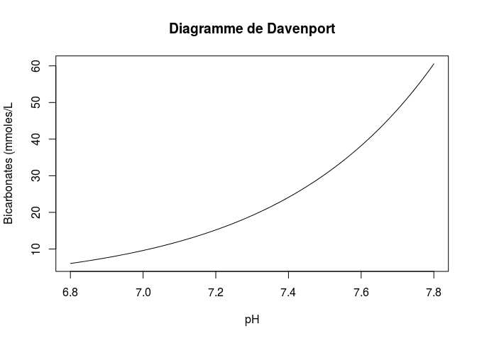